# Extraction de contours

Ce TP va vous faire appréhender le problème de l'extraction de contours en vous proposant d'implémenter et d'expérimenter une partie des concepts vus en cours.

## Set Up

```python
from collections import defaultdict
from pathlib import Path
from PIL import Image
import numpy as np
import matplotlib.pyplot as plt
from scipy import ndimage
from scipy.ndimage.measurements import label
import math
```

```python
image = Image.open("batG.png")
image = np.array(image)
```

```
(-0.5, 591.5, 513.5, -0.5)
```

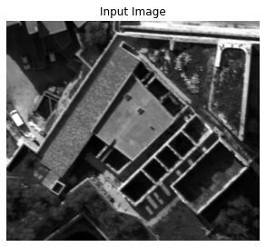

```python
fig = plt.figure(figsize = (5, 5))
plt.imshow(image, cmap="gray")
plt.title("Input Image")
plt.axis("off")
```

## Filtrage Dérivatif

### Exercice 1

Trouvez une fonction qui applique un filtre gaussien de variance $\sigma$ à l'image de votre choix.

```python
def gaussian(image, **kwargs):
    return ndimage.gaussian_filter(image.astype("float"), **kwargs)
```

```python
sigma = 3
image_blurred = gaussian(image, sigma=sigma)
```

```
(-0.5, 591.5, 513.5, -0.5)
```

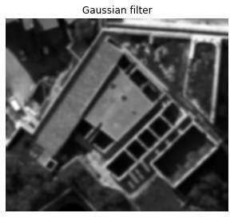

```python
fig = plt.figure(figsize = (5, 5))
plt.imshow(image_blurred, cmap="gray")
plt.title("Gaussian filter")
plt.axis("off")
```

### Exercice 2

Trouvez une fonction permettant de réaliser une convolution d'image. En utilisant le cours, construisez des noyeaux de convolution simples pour calculer le gradient en colonnes, le gradient en ligne et le Laplacien d'une image.

```python
# Vertical sobel filter
SOBEL_X = np.array([[-1.0, 0.0, 1.0],
                    [-2.0, 0.0, 2.0],
                    [-1.0, 0.0, 1.0]])
# Horizontal sobel filter
SOBEL_Y = - SOBEL_X.T
```

```python
def gradient_sobel(image, sigma=1):
    image_blurred = gaussian(image, sigma=sigma)
    dx = ndimage.filters.convolve(image_blurred.astype("float"), SOBEL_X)
    dy = ndimage.filters.convolve(image_blurred.astype("float"), SOBEL_Y)
    return dx, dy
```

```python
image_dx, image_dy = gradient_sobel(image, sigma=3)
```

```
(-0.5, 591.5, 513.5, -0.5)
```

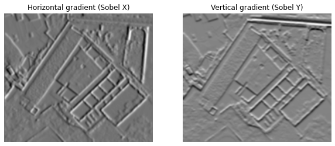

```python
fig = plt.figure(figsize = (10, 5))
ax1 = fig.add_subplot(121)
ax2 = fig.add_subplot(122)

ax1.imshow(image_dx, cmap="gray")
ax1.set_title("Horizontal gradient (Sobel X)")
ax1.axis("off")

ax2.imshow(image_dy, cmap="gray")
ax2.set_title("Vertical gradient (Sobel Y)")
ax2.axis("off")
```

### Exercice 3

Testez ces opérateurs différentiels sur une image filtrée pour différentes valeurs de $\sigma$.

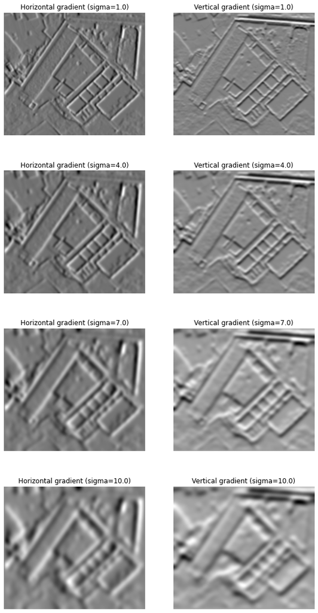

```python
fig = plt.figure(figsize = (10, 20))
rows = 4
sigmas = np.linspace(1, 10, rows)

# Create the mosaic
for i, sigma in enumerate(sigmas):
    img_dx, img_dy = gradient_sobel(image_blurred, sigma=sigma)
    fig.add_subplot(rows, 2, i * 2 + 1)
    plt.imshow(img_dx, cmap="gray")
    plt.title(f"Horizontal gradient (sigma={sigma:.1f})")
    plt.axis('off')

    fig.add_subplot(rows, 2, i * 2 + 2)
    plt.imshow(img_dy, cmap="gray")
    plt.title(f"Vertical gradient (sigma={sigma:.1f})")
    plt.axis('off')

# Render
plt.show()
```

### Exercice 4

Calculez le module du gradient à partir des gradients en ligne et en colonne:

$$ \|g\| = \sqrt{g_c^2 + g_l^2} $$

```python
def gradient_norm(image_dx, image_dy):
    return np.sqrt(image_dx ** 2 + image_dy ** 2)
```

```python
dimage = gradient_norm(image_dx, image_dy)
```

```
(-0.5, 591.5, 513.5, -0.5)
```

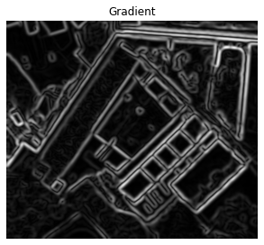

```python
fig = plt.figure(figsize = (5, 5))
plt.imshow(dimage, cmap="gray")
plt.title("Gradient")
plt.axis("off")
```

### Exercice 5

Calculez le gradient normalisé:

$$ \hat{g} = \frac{g}{\|g\|} $$

```python
image_dx_norm = np.divide(image_dx, dimage, out=np.zeros_like(image_dx), where=dimage!=0)
image_dy_norm = np.divide(image_dy, dimage, out=np.zeros_like(image_dx), where=dimage!=0)
```

```
(-0.5, 591.5, 513.5, -0.5)
```

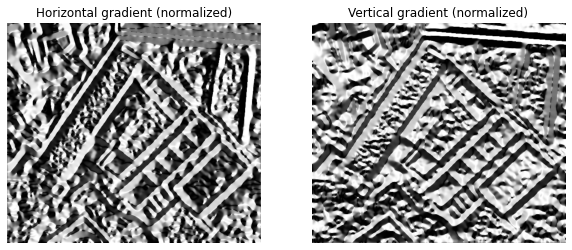

```python
fig = plt.figure(figsize = (10, 5))
ax1 = fig.add_subplot(121)
ax2 = fig.add_subplot(122)

ax1.imshow(image_dx_norm, cmap="gray")
ax1.set_title("Horizontal gradient (normalized)")
ax1.axis("off")

ax2.imshow(image_dy_norm, cmap="gray")
ax2.set_title("Vertical gradient (normalized)")
ax2.axis("off")
```

### Exercice 6

Calculez le gradient snappé:

$$ g_{snap} = snap(\frac{\hat{g}}{sin(\frac{\pi}{8})}) $$$$ snap(x) = \begin{cases} -1 \quad si \; x < - 1 \\ 1 \quad si \; x > 1 \\ 0 \quad sinon \end{cases} $$

```python
def snap(array):
    out_array = np.zeros_like(array)
    out_array[array < -1] = -1
    out_array[array > 1] = 1
    return out_array

def snap_gradient(gradient):
    gradient_snap = snap(gradient / np.sin(math.pi / 8))
    return gradient_snap
```

```python
dimage_sx = snap_gradient(image_dx_norm)
dimage_sy = snap_gradient(image_dy_norm)
```

```
(-0.5, 591.5, 513.5, -0.5)
```

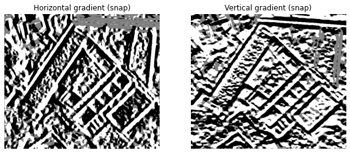

```python
fig = plt.figure(figsize = (10, 5))
ax1 = fig.add_subplot(121)
ax2 = fig.add_subplot(122)

ax1.imshow(dimage_sx, cmap="gray")
ax1.set_title("Horizontal gradient (snap)")
ax1.axis("off")

ax2.imshow(dimage_sy, cmap="gray")
ax2.set_title("Vertical gradient (snap)")
ax2.axis("off")
```

## Extraction de contours

### Exercice 1

En utilisant le code de la section précédente et le cours, écrire une fonction `ContoursCanny(image, sigma)` qui renvoie une image binaire des maxima du gradient dans la direction du gradient.

```python
def contours_canny(image, sigma=1, threshold=0, padding_mode="symmetric"):
    # Exercise 2
    image_dx, image_dy = gradient_sobel(image_blurred, sigma=sigma)
    # Exercise4
    dimage = gradient_norm(image_dx, image_dy)
    # Exercise 5
    image_dx_norm = np.divide(image_dx, dimage, out=np.zeros_like(image_dx), where=dimage!=0)
    image_dy_norm = np.divide(image_dy, dimage, out=np.zeros_like(image_dx), where=dimage!=0)
    # Exercise 6
    dimage_sx = snap_gradient(image_dx_norm)
    dimage_sy = snap_gradient(image_dy_norm)

    # Good practise: name the shape !
    rows, cols = image.shape

    # Tip: Pad the image to avoid edges issues
    dimage_padded = np.pad(dimage, pad_width=((1, 1), (1, 1)), mode=padding_mode)
    contours = np.zeros((rows, cols), dtype="bool")

    for i in range(rows):
        for j in range(cols):
            # Get the gradient orientation (dx, dy)
            dx, dy = int(dimage_sx[i, j]), int(dimage_sy[i, j])
            # Get the gradient value
            pixel_grad = dimage[i, j]
            # Get the neighbours i.r.o the gradient orientation
            # Note: x, y != i, j coordinates !
            # Note: don't forget padding indices !
            neighbours = [dimage_padded[i + dy + 1, j - dx + 1], dimage_padded[i - dy + 1, j + dx + 1]]
            # There is a contour if the gradient is above its neighbours
            if pixel_grad > max(neighbours) and abs(pixel_grad) > threshold:
                contours[i, j] = True

    return contours
```

```python
contours = contours_canny(image, sigma=3, threshold=0)
```

```
(-0.5, 591.5, 513.5, -0.5)
```

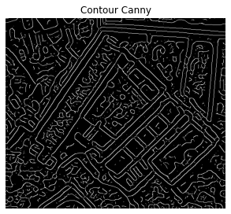

```python
fig = plt.figure(figsize = (5, 5))
plt.imshow(contours, cmap="gray")
plt.title("Contour Canny")
plt.axis("off")
```

### Exercice 2

Tester cette fonction sur une image. Que constatez vous ?

*Il y a beaucoup d'éléments détectés qui ne sont pas des contours, i.e. maximums locaux / faux positifs.*

### Exercice 3

Modifiez la fonction pour qu'elle prenne un seuil en argument, et ne gardez que les maxima dont le module est supérieur au seuil.

```python
contours = contours_canny(image, sigma=3, threshold=64)
```

```
(-0.5, 591.5, 513.5, -0.5)
```

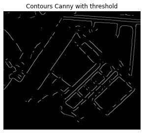

```python
fig = plt.figure(figsize = (5, 5))
plt.imshow(contours, cmap="gray")
plt.title("Contours Canny with threshold")
plt.axis("off")
```

### Exercice 4

Comparez avec un seuillage sur le module du gradient. Quel est l'intérêt de cette méthode ?

```python
def threshold_gradient(gradient, threshold=0):
    return np.where(gradient > threshold, True, False)
```

```python
contours = threshold_gradient(dimage, threshold=100)
```

```
(-0.5, 591.5, 513.5, -0.5)
```

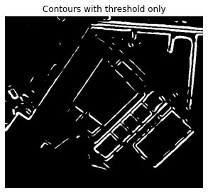

```python
fig = plt.figure(figsize = (5, 5))
plt.imshow(contours, cmap="gray")
plt.title("Contours with threshold only")
plt.axis("off")
```

*L'intérêt de cette méthode est de réduire les faux positifs détéctés.*

### Exercice 5

Seuillez le Laplacien d'une image (à 0) pour différents $\sigma$.

```python
LAPLACIAN = np.array([[ 0, -1,  0],
                      [-1,  4, -1],
                      [ 0, -1,  0]])
```

```python
def gradient_laplacian(image, sigma=1):
    image_blurred = gaussian(image, sigma=sigma)
    dimage = ndimage.filters.convolve(image_blurred.astype("float"), LAPLACIAN)
    return dimage
```

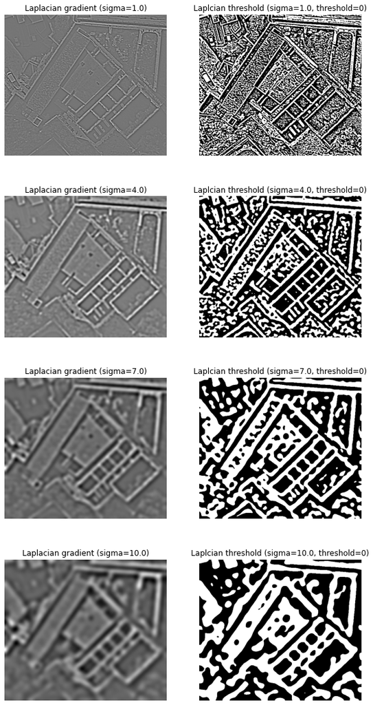

```python
fig = plt.figure(figsize = (10, 20))
rows = 4
sigmas = np.linspace(1, 10, rows)

# Create the mosaic
for i, sigma in enumerate(sigmas):
    dimage = gradient_laplacian(image, sigma=sigma)
    contours = threshold_gradient(dimage, threshold=0)
    fig.add_subplot(rows, 2, i * 2 + 1)
    plt.imshow(dimage, cmap="gray")
    plt.title(f"Laplacian gradient (sigma={sigma:.1f})")
    plt.axis('off')

    fig.add_subplot(rows, 2, i * 2 + 2)
    plt.imshow(contours, cmap="gray")
    plt.title(f"Laplcian threshold (sigma={sigma:.1f}, threshold=0)")
    plt.axis('off')

# Render
plt.show()
```

### Exercice 6

Ecrire une fonction `ContoursLaplace(image, sigma)` qui renvoie une image binaire des pixels de Lapacien positif qui ont au moins un voisin de Laplacien négatif.

```python
def contours_laplace(image, gradient=None, sigma=1, threshold=0, padding_mode="symmetric"):
    # Compute the gradient with a Laplacian filter
    dimage = gradient_laplacian(image, sigma=sigma)
    dimage = threshold_gradient(dimage, threshold=threshold)
    # Tip: Pad the image to avoid edges issues
    dimage_padded = np.pad(dimage, pad_width=((1, 1), (1, 1)), mode=padding_mode)

    # Good practise: name the shape
    rows, cols = image.shape

    # Output contours map
    contours = np.zeros((rows, cols), dtype="bool")

    for i in range(rows):
        for j in range(cols):
            # Get the gradient value
            grad_value = dimage[i, j]
            if grad_value:
                # Get its neighbours
                neighbours = dimage_padded[i:i+3 , j:j+3]
                neighbours_neg = neighbours[neighbours == False]
                # If there are negative values
                if neighbours_neg.size > 0:
                    contours[i, j] = True

    return contours
```

```python
contours = contours_laplace(image, sigma=3, threshold=0, padding_mode="symmetric")
```

```
(-0.5, 591.5, 513.5, -0.5)
```

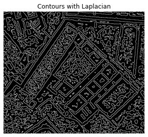

```python
fig = plt.figure(figsize = (5, 5))
plt.imshow(contours, cmap="gray")
plt.title("Contours with Laplacian")
plt.axis("off")
```

### Exercice 7

Modifiez la fonction pour qu'elle prenne un seuil en argument, et ne gardez que les pixels pour lesquels le max des différences (en niveau de gris) avec un de ses voisins négatifs est supérieure à un seuil donné.

```python
def contours_laplace(image, sigma=1, threshold=0, padding_mode="symmetric"):
    # Compute the gradient with a Laplacian filter
    dimage = gradient_laplacian(image, sigma=sigma)
    # Tip: Pad the image to avoid edges issues
    dimage_padded = np.pad(dimage, pad_width=((1, 1), (1, 1)), mode=padding_mode)

    # Good practise: name the shape
    rows, cols = image.shape

    # Output contours map
    contours = np.zeros((rows, cols), dtype="bool")

    for i in range(rows):
        for j in range(cols):
            # Get the gradient value
            grad_value = dimage[i, j]

            # Compute the contour for positive gradients
            if grad_value > 0:
                # Get its neighbours
                neighbours = dimage_padded[i:i+3 , j:j+3]
                neighbours_neg = neighbours[neighbours < 0]
                # If there are negative values
                if neighbours_neg.size > 0:
                    grad_diff = grad_value - neighbours_neg.min()
                    if grad_diff > threshold:
                        contours[i, j] = True

    return contours
```

```python
contours = contours_laplace(image, sigma=3, threshold=2, padding_mode="symmetric")
```

```
(-0.5, 591.5, 513.5, -0.5)
```

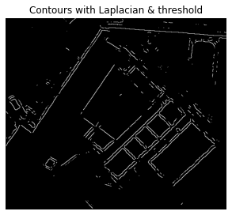

```python
fig = plt.figure(figsize = (5, 5))
plt.imshow(contours, cmap="gray")
plt.title("Contours with Laplacian & threshold")
plt.axis("off")
```

### Exercice 8

Quelles sont les différences notables avec l'approche précédente ?

*Cette méthode permet de réduire les faux positifs en seuillant le laplacien par `threshold`. Les valeurs seuillées correspondent à du bruit i.e. des objets qui ne sont pas des contours.*

## Optionel: Filtrage par hystérésis

### Exercice 1

Implémenter une fonction `Cluster(contours)` qui regroupe les pixels adjacent d'un masque de contours (avec un seuil bas) dans une liste de listes de paires $(l, c)$. On pourra utiliser une pile pour stocker les pixels à traiter et une image binaire indiquant si un pixel a déjà été traité.

```python
contours_test = np.array([[1, 0, 1, 0, 0, 1, 0, 0, 1, 0, 0],
                          [0, 0, 0, 1, 0, 1, 0, 1, 0, 1, 0],
                          [0, 0, 0, 1, 0, 1, 0, 1, 1, 0, 0],
                          [1, 1, 0, 0, 1, 0, 0, 0, 1, 0, 0],
                          [0, 1, 1, 0, 0, 0, 1, 1, 0, 0, 1],
                          [1, 0, 0, 0, 1, 1, 0, 1, 1, 1, 0],
                          [1, 0, 0, 0, 0, 1, 0, 0, 0, 0, 0],
                          [0, 1, 1, 0, 0, 0, 1, 0, 0, 0, 0],
                          [0, 0, 1, 0, 0, 1, 1, 0, 0, 1, 0],
                          [0, 0, 0, 0, 0, 1, 0, 0, 1, 0, 1],
                          [0, 1, 1, 0, 1, 0, 0, 0, 0, 0, 1],
                          [1, 0, 0, 0, 1, 0, 1, 1, 1, 1, 0]])
```

```
(-0.5, 10.5, 11.5, -0.5)
```

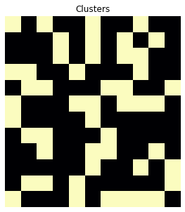

```python
fig = plt.figure(figsize = (5, 5))
plt.imshow(contours_test, cmap="magma")
plt.title("Clusters")
plt.axis("off")
```

```python
def find_clusters(contours, structure=None, padding_mode="symmetric"):
    # Initialize the first cluster id
    cluster_id = 0
    # Create the structure element, used to tell if a pixel belongs to a cluster
    structure = np.array(structure).astype("int") if structure is not None else np.ones((3, 3), dtype="int")
    assert structure.ndim == 2, f"The rank of the structure element must be 2, got {structure.ndim}"

    # Tip: Pad the contour to avoid edges issues
    contours = contours.astype("int")
    pad_rows, pad_cols = structure.shape[0] // 2, structure.shape[1] // 2
    contours_padded = np.pad(contours, pad_width=((pad_rows, pad_rows), (pad_cols, pad_cols)), mode=padding_mode)
    # Binary map used to map clustered pixels and unknown ones
    # Note: also pad this map to avoid edges issues
    clusters_map = np.zeros_like(contours_padded)

    # Good practise: name the shape
    rows, cols = contours.shape

    for i in range(rows):
        for j in range(cols):
            contours_pixel = contours_padded[i+1, j+1]
            # If the pixel belongs to a contour
            if contours_pixel:
                neighbours = clusters_map[i:i+3, j:j+3] * structure

                # Get the clusters id from the map (ignore background id i.e. 0)
                clusters_id = neighbours[neighbours > 0]
                # If it's not a new contour, i.e. has neighbours
                if clusters_id.size > 0:
                    # Retrieve the cluster id
                    main_cluster_id = clusters_id.min()
                    # Add the current element
                    clusters_map[i+1, j+1] = main_cluster_id
                    # If two (or more) clusters are connected, merge them
                    if main_cluster_id < cluster_id:
                        for cid in clusters_id:
                            # Merge the clusters on the map
                            clusters_map[clusters_map == cid] = main_cluster_id

                # If it's a new cluster
                else:
                    cluster_id += 1
                    clusters_map[i+1, j+1] = cluster_id

    # Optional:
    # Make continuous cluster ids (eg. ids = [1, 3, 6, 12] -> [1, 2, 3, 4])
    clusters_map = clusters_map[1:-1, 1:-1]
    clusters_id = np.unique(clusters_map[clusters_map > 0])
    for i, cluster_id in enumerate(clusters_id):
        clusters_map[clusters_map == cluster_id] = i + 1

    return clusters_map, len(clusters_id)
```

```python
# 4 connexity
structure = np.array([[0, 1, 0],
                      [1, 1, 1],
                      [0, 1, 0]])
clusters_map_4, num_clusters_4 = find_clusters(contours_test, structure=structure)

# 8 connexity
structure = np.array([[1, 1, 1],
                      [1, 1, 1],
                      [1, 1, 1]])
clusters_map_8, num_clusters_8 = find_clusters(contours_test, structure=structure)
```

```
(-0.5, 10.5, 11.5, -0.5)
```

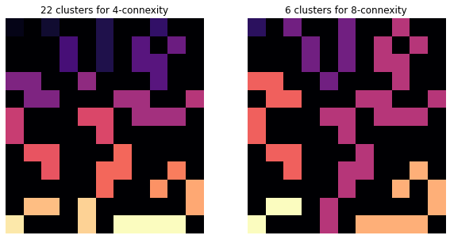

```python
fig = plt.figure(figsize = (10, 5))
ax1 = fig.add_subplot(121)
ax2 = fig.add_subplot(122)

ax1.imshow(clusters_map_4, cmap="magma")
ax1.set_title(f"{num_clusters_4} clusters for 4-connexity")
ax1.axis("off")

ax2.imshow(clusters_map_8, cmap="magma")
ax2.set_title(f"{num_clusters_8} clusters for 8-connexity")
ax2.axis("off")
```

*SciPy a déjà implémenté cette fonction, qui se nomme `label`. J'utilise celle ci pour la suite du TP, car est plus rapide.*

```python
# Fast clustering
def find_clusters(contours, structure=None):
    structure = np.array(structure).astype("int") if structure is not None else np.ones((3, 3), dtype="int")
    clusters_map, num_clusters = label(contours, structure)
    return clusters_map, num_clusters
```

### Exercice 2

Implémenter une fonction `Hyst(contours, gradnorm, seuil)` qui produit un nouveau masque de contours avec seulement les clusters ayant au moins un pixel pour lequel le module du gradient est supérieur au seuil.

```python
def hysteresis(contours, gradient, threshold=0, structure=None):
    clusters_map, num_clusters = find_clusters(contours, structure=structure)

    assert contours.shape == gradient.shape, "The contours and gradient must have the same shape"
    rows, cols = contours.shape
    out_contours = np.zeros((rows, cols))

    # Create a list of contour
    contours_list = [np.where(clusters_map == contour_id, True, False) for contour_id in range(1, num_clusters+1)]
    for contour in contours_list:
        contour_gradient = contour * gradient
        if contour_gradient[contour_gradient > threshold].size > 0:
            out_contours += contour

    return out_contours.astype("bool")
```

### Exercice 3

Remplacer le seuil dans les fonctions `ContoursCanny` et `ContoursLaplace` par deux seuils hauts et bas, et utiliser la fonction `Hyst` pour appliquer le seuillage par hystérésis aux résultats de ces deux fonctions. Pour `ContoursLaplace`, on pourra stocker la différence de niveaux de gris sur laquelle agit le seuil pour la passer à `Hyst`.

#### Canny w/ hysteresis

```python
def contours_canny_hysteresis(image, sigma=1, threshold_min=0, threshold_max=np.inf, padding_mode="symmetric"):
    image_dx, image_dy = gradient_sobel(image)
    dimage = gradient_norm(image_dx, image_dy)
    contours = contours_canny(image, sigma=sigma, threshold=threshold_min, padding_mode="symmetric")
    contours = hysteresis(contours, dimage, threshold=threshold_max)
    return contours
```

```python
contours = contours_canny(image, sigma=3, threshold=100)
hyst_contours = contours_canny_hysteresis(image, sigma=3, threshold_min=64, threshold_max=100)
```

```
(-0.5, 591.5, 513.5, -0.5)
```

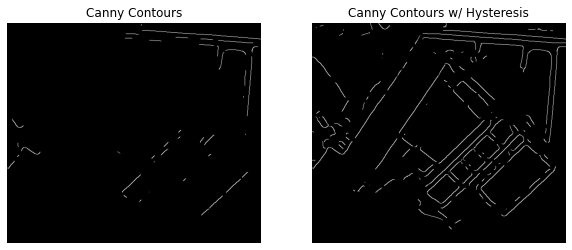

```python
fig = plt.figure(figsize = (10, 5))
ax1 = fig.add_subplot(121)
ax2 = fig.add_subplot(122)

ax1.imshow(contours, cmap="gray")
ax1.set_title("Canny Contours")
ax1.axis("off")

ax2.imshow(hyst_contours, cmap="gray")
ax2.set_title("Canny Contours w/ Hysteresis")
ax2.axis("off")
```

```python
def contours_laplace_hysteresis(image, sigma=1, threshold_min=0, threshold_max=np.inf, padding_mode="symmetric"):
    dimage = gradient_laplacian(image, sigma=sigma)
    contours = contours_laplace(image, sigma=sigma, threshold=threshold_min, padding_mode="symmetric")
    contours = hysteresis(contours, dimage, threshold=threshold_max)
    return contours
```

#### Laplacian w/ hysteresis

```python
contours = contours_laplace(image, sigma=3, threshold=2)
hyst_contours = contours_laplace_hysteresis(image, sigma=3, threshold_min=1, threshold_max=2)
```

```
(-0.5, 591.5, 513.5, -0.5)
```

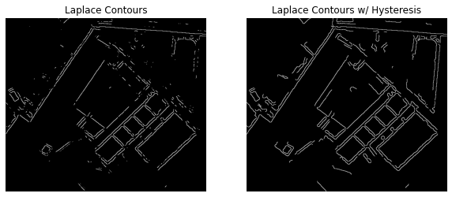

```python
fig = plt.figure(figsize = (10, 5))
ax1 = fig.add_subplot(121)
ax2 = fig.add_subplot(122)

ax1.imshow(contours, cmap="gray")
ax1.set_title("Laplace Contours")
ax1.axis("off")

ax2.imshow(hyst_contours, cmap="gray")
ax2.set_title("Laplace Contours w/ Hysteresis")
ax2.axis("off")
```